# Kansas Choropleth Map

## Details about the function

This automates the procedure of generating choropleth maps, but this automation means that you have a tradeoff with less flexibility. In case you find yourself consistently wanting the plots to look different, I will explain the code so that you can edit it how you wish.

```r
ks_map <- function(data, key, variable, label="", lowcolor="#56B1F7", highcolor="#132B43", title="") {
```

```r
  # loading packages
  suppressPackageStartupMessages(require(ggplot2))
  suppressPackageStartupMessages(require(ggmap))
  suppressPackageStartupMessages(require(maps))
  suppressPackageStartupMessages(require(dplyr))
  suppressPackageStartupMessages(require(tidyr))
```

These lines load the necessary packages. Some of these give you messages upon starting them, so I have surrounded each with the function that will suppress these package startup messages.

```r
  # get mapping data
  mapdata <- map_data("county", "kansas")
```

This loads the county-level data for kansas from the `ggplot2` package. It contains county names and the points for plotting the county lines.

```r
  # combine with fips codes
  data("county.fips", envir=environment())
```

Sometimes you may have FIPS codes, but not county names. This call to `data` loads the `"county.fips"` data from the `maps` package.

```r
  mapdata <- county.fips %>%
    separate(polyname, c("region", "subregion"), "[,]") %>%
    filter(region=="kansas") %>%
    select(-region) %>%
    full_join(mapdata, by="subregion") %>%
    rename(county=subregion) %>%
    select(-region)
```

This `dplyr` pipe chain takes `county.fips` data and merges it with the `mapdata`.

```r
  if (key=="fips") {
    mapdata <- left_join(mapdata, data, by="fips")
    plot <- ggplot(mapdata, aes(x=long, y=lat, group=group, fill=get(variable))) +
      geom_polygon() +
      coord_map() +
      theme_void() +
      scale_fill_gradient(name=label, low=lowcolor, high=highcolor) +
      labs(title=title)
    return(plot)
```

It uses `geom_polygon` to draw the counties, `coord_map` to make sure Kansas has the right dimensions, `theme_void` to get rid of all axes and the default `ggplot2` background, `scale_fill_gradient` to specify the label you are giving your variable in the legend (as well as the colors). Finally, it makes a call to `labs` to make the title name. It then returns the plot you just made.

```r
  } else if (key=="county") {
    mapdata <- left_join(mapdata, data, by="county")
    plot <- ggplot(mapdata, aes(x=long, y=lat, group=group, fill=get(variable))) +
      geom_polygon() +
      coord_map() +
      theme_void() +
      scale_fill_gradient(name=label, low=lowcolor, high=highcolor) +
      labs(title=title)
    return(plot)
```

This does the same thing as above, except now it is using county names instead of FIPS codes.

```r
  } else {
    stop("Please specify key as either 'county' or 'fips'")
  }
}
```

The last part of the function throws an error. If you do not specify the key as either `"county"` or `"fips"`, then you get an error, because the function does not know where to join the mapping data with your data.

For example, there are different types of projections you can use with `coord_map`, [see the documentation](http://ggplot2.tidyverse.org/reference/coord_map.html) for `coord_map` for details.

By default, `coord_map` uses as `"mercator"` projection (i.e., “equally spaced straight meridians, conformal, straight compass courses”). You could also specify another projection. For instance, “`stereographic`” (i.e., “conformal, projected from opposite pole”):

```r
ggplot(mapdata, aes(x=long, y=lat, group=group, fill=get(variable))) +
      geom_polygon() +
      coord_map("stereographic") + # specify a different projection here
      theme_void() +
      scale_fill_gradient(name=label, low=lowcolor, high=highcolor) +
      labs(title=title)
```

If you put this into the function, you would get a map that looks like this:

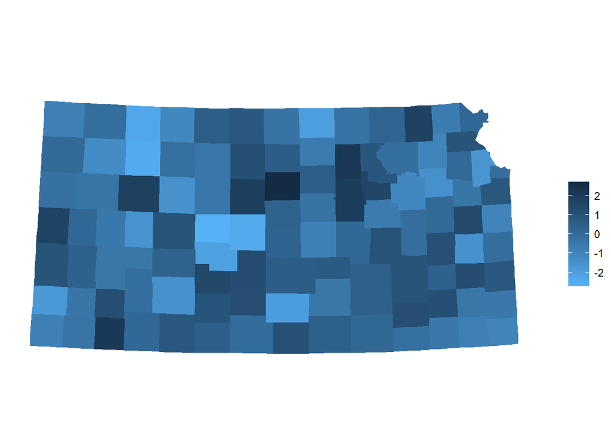

```r
ks_map(test, "county", "var")
```